# Binary Logistic DrPH (Epidemiology)

Kamarul Imran M

1 February 2016

# Modeling Binomial Data

1. Describe data
2. Explore data - Exploratory Data Analysis
3. Estimate parameters
4. Make Inference
5. Make Prediction
6. Interpretation

# Locate files

- Browse your folders.
- Look for the files.
- Check the path to the folder containing the files

# Set the folder

Set our working directory. REMEMBER! your working directory (working folder) is different from my working directory

```r
# this is my working directory. You have to specify yours
setwd("/Volumes/DATA/1-LectureNotes-Kims/LectureNotes2015/binary-logistic/binary-logistic-DrPH-2015/BinaryLogisticDrPH-Epid/BinaryLog-DrPH-Epid")
getwd()
```

```
## [1] "/Volumes/DATA/1-LectureNotes-Kims/LectureNotes2015/binary-logistic/binary-logistic-DrPH-2015/BinaryLogisticDrPH-Epid/BinaryLog-DrPH-Epid"
```

# Read data

- Read our data in the working folder
- Then, save as a csv file in our working directory

```r
mydata <- read.csv("http://www.ats.ucla.edu/stat/data/binary.csv")
write.csv2(mydata,'logistic.csv')
```

# Describe data

```r
#observe data
head(mydata,10)
```

[output not shown]

Rank is taken as numerical variable which does not make sense. We need to convert it to a categorical (factor) variable

```r
summary(mydata)
```

```
##      admit             gre             gpa             rank
##  Min.   :0.0000   Min.   :220.0   Min.   :2.260   Min.   :1.000
##  1st Qu.:0.0000   1st Qu.:520.0   1st Qu.:3.130   1st Qu.:2.000
##  Median :0.0000   Median :580.0   Median :3.395   Median :2.000
##  Mean   :0.3175   Mean   :587.7   Mean   :3.390   Mean   :2.485
##  3rd Qu.:1.0000   3rd Qu.:660.0   3rd Qu.:3.670   3rd Qu.:3.000
##  Max.   :1.0000   Max.   :800.0   Max.   :4.000   Max.   :4.000
```

```r
mydata$rank<-factor(mydata$rank)
summary(mydata$rank)
```

```
##   1   2   3   4
##  61 151 121  67
```

# Explore data

Use plots like * Histogram for numerical variables * and barplot for categorical variables, at least.

# Estimate parameters

- we estimate the logit or the log odds.
- We used **summary** to see the results stored as **mylogit**
- We used **coefficients** to examine the regression coefficients

```r
mylogit <- glm(admit~gre+gpa+rank,family = 'binomial'(link = logit),data=mydata)
summary(mylogit)
```

```
##
## Call:
## glm(formula = admit ~ gre + gpa + rank, family = binomial(link = logit),
##     data = mydata)
##
## Deviance Residuals:
##     Min       1Q   Median       3Q      Max
## -1.6268  -0.8662  -0.6388   1.1490   2.0790
##
## Coefficients:
##              Estimate Std. Error z value Pr(>|z|)
## (Intercept) -3.989979   1.139951  -3.500 0.000465 ***
## gre          0.002264   0.001094   2.070 0.038465 *
## gpa          0.804038   0.331819   2.423 0.015388 *
## rank2       -0.675443   0.316490  -2.134 0.032829 *
## rank3       -1.340204   0.345306  -3.881 0.000104 ***
## rank4       -1.551464   0.417832  -3.713 0.000205 ***
## ---
## Signif. codes:  0 '***' 0.001 '**' 0.01 '*' 0.05 '.' 0.1 ' ' 1
##
## (Dispersion parameter for binomial family taken to be 1)
##
##     Null deviance: 499.98  on 399  degrees of freedom
## Residual deviance: 458.52  on 394  degrees of freedom
## AIC: 470.52
##
## Number of Fisher Scoring iterations: 4
```

```r
coefficients(mylogit)
```

```
##  (Intercept)          gre          gpa        rank2        rank3
## -3.989979073  0.002264426  0.804037549 -0.675442928 -1.340203916
##        rank4
## -1.551463677
```

To obtain the odds ratios and their 95% CI, we need to exponentiate using **exp** the regression coefficients or the betas

```r
exp(coefficients(mylogit))
```

```
## (Intercept)         gre         gpa       rank2       rank3       rank4
##   0.0185001   1.0022670   2.2345448   0.5089310   0.2617923   0.2119375
```

```r
exp(confint(mylogit))
```

```
##                   2.5 %    97.5 %
## (Intercept) 0.001889165 0.1665354
## gre         1.000137602 1.0044457
## gpa         1.173858216 4.3238349
## rank2       0.272289674 0.9448343
## rank3       0.131641717 0.5115181
## rank4       0.090715546 0.4706961
```

# Make inference

Here, we examine the p-values (hypothesis testing) and the confidence intervals.

- First, using the method of maximum likelihood
- Next, using the SE method (function **confint.default**)

```r
confint(mylogit)
```

```
##                     2.5 %       97.5 %
## (Intercept) -6.2716202334 -1.792547080
## gre          0.0001375921  0.004435874
## gpa          0.1602959439  1.464142727
## rank2       -1.3008888002 -0.056745722
## rank3       -2.0276713127 -0.670372346
## rank4       -2.4000265384 -0.753542605
```

```r
confint.default(mylogit)
```

```
##                     2.5 %       97.5 %
## (Intercept) -6.2242418514 -1.755716295
## gre          0.0001202298  0.004408622
## gpa          0.1536836760  1.454391423
## rank2       -1.2957512650 -0.055134591
## rank3       -2.0169920597 -0.663415773
## rank4       -2.3703986294 -0.732528724
```

# Make prediction

We now can:

1. Predict the log odds for having the outcome
2. Predict the conditional probability for having the outcome

```r
pred.logit<-predict(mylogit,type='link')
head(pred.logit)
```

```
##          1          2          3          4          5          6
## -1.5671256 -0.8848442  1.0377118 -1.5273305 -2.0081113 -0.5323458
```

```r
-3.99+0.00226*380+0.8041*3.61-1.34
```

```
## [1] -1.568399
```

Notice, that similarity between **predict(x, type=‘response’** and **fitted** Remember, we can calculate the conditional probability of having the outcome

```r
pred.prob<-predict(mylogit,type='response')
head(pred.prob)
```

```
##         1         2         3         4         5         6
## 0.1726265 0.2921750 0.7384082 0.1783846 0.1183539 0.3699699
```

```r
head(fitted(mylogit))
```

```
##         1         2         3         4         5         6
## 0.1726265 0.2921750 0.7384082 0.1783846 0.1183539 0.3699699
```

```r
exp(-1.567)/(1+exp(-1.567))
```

```
## [1] 0.1726445
```

# Comparing models

We compare a model with **vs** and without **gre**. This is done using the deviance

```r
summary(mylogit)
```

```
##
## Call:
## glm(formula = admit ~ gre + gpa + rank, family = binomial(link = logit),
##     data = mydata)
##
## Deviance Residuals:
##     Min       1Q   Median       3Q      Max
## -1.6268  -0.8662  -0.6388   1.1490   2.0790
##
## Coefficients:
##              Estimate Std. Error z value Pr(>|z|)
## (Intercept) -3.989979   1.139951  -3.500 0.000465 ***
## gre          0.002264   0.001094   2.070 0.038465 *
## gpa          0.804038   0.331819   2.423 0.015388 *
## rank2       -0.675443   0.316490  -2.134 0.032829 *
## rank3       -1.340204   0.345306  -3.881 0.000104 ***
## rank4       -1.551464   0.417832  -3.713 0.000205 ***
## ---
## Signif. codes:  0 '***' 0.001 '**' 0.01 '*' 0.05 '.' 0.1 ' ' 1
##
## (Dispersion parameter for binomial family taken to be 1)
##
##     Null deviance: 499.98  on 399  degrees of freedom
## Residual deviance: 458.52  on 394  degrees of freedom
## AIC: 470.52
##
## Number of Fisher Scoring iterations: 4
```

```r
mylogit2 <- glm(admit~gpa+rank,family = 'binomial'(link = logit),data=mydata)
summary(mylogit2)
```

```
##
## Call:
## glm(formula = admit ~ gpa + rank, family = binomial(link = logit),
##     data = mydata)
##
## Deviance Residuals:
##     Min       1Q   Median       3Q      Max
## -1.5055  -0.8663  -0.6590   1.1505   2.0913
##
## Coefficients:
##             Estimate Std. Error z value Pr(>|z|)
## (Intercept)  -3.4636     1.1003  -3.148 0.001645 **
## gpa           1.0521     0.3102   3.392 0.000694 ***
## rank2        -0.6810     0.3141  -2.168 0.030181 *
## rank3        -1.3919     0.3419  -4.071 4.68e-05 ***
## rank4        -1.5943     0.4152  -3.840 0.000123 ***
## ---
## Signif. codes:  0 '***' 0.001 '**' 0.01 '*' 0.05 '.' 0.1 ' ' 1
##
## (Dispersion parameter for binomial family taken to be 1)
##
##     Null deviance: 499.98  on 399  degrees of freedom
## Residual deviance: 462.88  on 395  degrees of freedom
## AIC: 472.88
##
## Number of Fisher Scoring iterations: 4
```

```r
anova(mylogit,mylogit2,test = 'Chisq')
```

```
## Analysis of Deviance Table
##
## Model 1: admit ~ gre + gpa + rank
## Model 2: admit ~ gpa + rank
##   Resid. Df Resid. Dev Df Deviance Pr(>Chi)
## 1       394     458.52
## 2       395     462.88 -1  -4.3578  0.03684 *
## ---
## Signif. codes:  0 '***' 0.001 '**' 0.01 '*' 0.05 '.' 0.1 ' ' 1
```

# Linearity in logits

**gre** is tested for linearity in logit. **gre** is linear but it is rescaled to produce less decimals

The linearity of logits is tested using library **mfp**

```r
library(mfp)
mylogit3 <- mfp(admit~fp(gre)+gpa+rank,family = 'binomial'(link = logit),data=mydata,verbose=T)
```

```
##
##  Variable    Deviance    Power(s)
## ------------------------------------------------
## Cycle 1
##  rank2
##              463.096
##              458.517     1
##
##
##
##  rank3
##              474.043
##              458.517     1
##
##
##
##  rank4
##              473.551
##              458.517     1
##
##
##
##  gpa
##              464.532
##              458.517     1
##
##
##
##  gre
##              462.875
##              458.517     1
##              458.415     0
##              458.366     -2 -2
##
##
## Tansformation
##       shift scale
## rank2     0     1
## rank3     0     1
## rank4     0     1
```

[output cut: 9 more lines]

```
## gre            4      1  0.05        1      1      .
##
##
## Transformations of covariates:
##              formula
## gre  I((gre/1000)^1)
## gpa              gpa
## rank            rank
##
##
## Deviance table:
##           Resid. Dev
## Null model    499.9765
## Linear model  458.5175
## Final model   458.5175
```

```r
summary(mylogit3)
```

```
##
## Call:
## glm(formula = admit ~ rank + gpa + I((gre/1000)^1), family = binomial(link = logit),
##     data = mydata)
##
## Deviance Residuals:
##     Min       1Q   Median       3Q      Max
## -1.6268  -0.8662  -0.6388   1.1490   2.0790
##
## Coefficients:
##                 Estimate Std. Error z value Pr(>|z|)
## (Intercept)      -3.9900     1.1400  -3.500 0.000465 ***
## rank2            -0.6754     0.3165  -2.134 0.032829 *
## rank3            -1.3402     0.3453  -3.881 0.000104 ***
## rank4            -1.5515     0.4178  -3.713 0.000205 ***
## gpa               0.8040     0.3318   2.423 0.015388 *
## I((gre/1000)^1)   2.2644     1.0940   2.070 0.038465 *
## ---
## Signif. codes:  0 '***' 0.001 '**' 0.01 '*' 0.05 '.' 0.1 ' ' 1
##
## (Dispersion parameter for binomial family taken to be 1)
##
##     Null deviance: 499.98  on 399  degrees of freedom
## Residual deviance: 458.52  on 394  degrees of freedom
## AIC: 470.52
##
## Number of Fisher Scoring iterations: 4
```

```r
mylogit3$fptable
```

```
##       df.initial select alpha df.final power1 power2
## rank2          1      1  0.05        1      1      .
## rank3          1      1  0.05        1      1      .
## rank4          1      1  0.05        1      1      .
## gpa            1      1  0.05        1      1      .
## gre            4      1  0.05        1      1      .
```

# Diagnostics for a Binomial Response

To do these diagnostics, you need to load **library(‘LogisticDx’)**.

First, we produce the diagnostic measures for a binary regression model by covariate pattern

Next, we produce the Goodness-of-fit for binomial regression. Usually, the number of groups (quantiles) equal 10 to perform the Hosmer-Lemeshow test. At the same time, we plot the ROC curve

Similarly, we can check the **auc** value

```r
library('LogisticDx')
dx(mylogit2,byCov=T)
```

```
##      (Intercept)  gpa rank2 rank3 rank4 y         P n      yhat
##   1:           1 3.94     1     0     0 1 0.5001242 2 1.0002483
##   2:           1 3.30     1     0     0 1 0.3378663 3 1.0135990
##   3:           1 3.99     0     1     0 1 0.3412259 3 1.0236777
##   4:           1 3.35     1     0     0 1 0.3497327 3 1.0491980
##   5:           1 3.17     1     0     0 1 0.3079792 3 0.9239375
##  ---
## 256:           1 3.52     0     0     1 2 0.2051122 3 0.6153366
## 257:           1 2.68     0     1     0 1 0.1154721 1 0.1154721
## 258:           1 3.00     0     0     1 1 0.1299149 1 0.1299149
## 259:           1 2.42     0     0     0 1 0.2854368 1 0.2854368
## 260:           1 2.65     0     1     0 1 0.1122874 1 0.1122874
##                 Pr            dr           h           sPr           sdr
##   1: -0.0003511985 -0.0003511985 0.014377039 -0.0003537507 -0.0003537506
##   2: -0.0165997514 -0.0166181074 0.006902268 -0.0166573376 -0.0166757573
```

[output cut: 21 more lines]

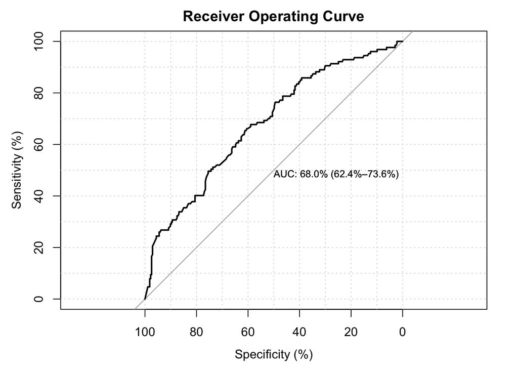

```r
fit.mylogit2<-gof(mylogit2,g=10,plotROC = T)
```

```r
fit.mylogit2
```

```
##       chiSq  df     pVal
## PrI  400.78 395 0.409645
## drI  462.88 395 0.010379 *
## PrG  255.36 255 0.481870
## drG  294.60 255 0.044609 *
## PrCT 255.36 255 0.481870
## drCT 294.60 255 0.044609 *
## ---
## Signif. codes:  0 '***' 0.001 '**' 0.01 '*' 0.05 '.' 0.1 ' ' 1
##                       val df     pVal
## HL chiSq         8.190458  8 0.415090
## mHL F            1.484491  9 0.153918
## OsRo Z           0.027903 NA 0.977740
## SstPgeq0.5 Z     0.217564 NA 0.827769
## SstPl0.5 Z       0.422859 NA 0.672398
## SstBoth chiSq    0.226144  2 0.893086
## SllPgeq0.5 chiSq 0.047739  1 0.827045
## SllPl0.5 chiSq   0.176745  1 0.674186
## SllBoth chiSq    0.177398  2 0.915121
```

```r
#area under curve
fit.mylogit2$auc
```

```
##          auc lower 95% CI upper 95% CI
##     68.01073     62.39737     73.62409
## attr(,"interpret")
## [1] "auc = 0.5       --> useless"   "0.7 < auc < 0.8 --> good"
## [3] "0.8 < auc < 0.9 --> excellent"
```

```r
#chi square test for gof
fit.mylogit2$chiSq
```

```
##    test    chiSq  df       pVal
## 1:  PrI 400.7833 395 0.40964543
## 2:  drI 462.8753 395 0.01037867
## 3:  PrG 255.3601 255 0.48187033
## 4:  drG 294.6050 255 0.04460896
## 5: PrCT 255.3601 255 0.48187033
## 6: drCT 294.6050 255 0.04460896
```

```r
#contigency table for HL test
fit.mylogit2$ctHL
```

```
##         P y1     y1hat y0    y0hat  n      Pbar
##  1: 0.149  6  5.037833 34 34.96217 40 0.1259458
##  2: 0.192  5  6.824095 35 33.17591 40 0.1706024
##  3: 0.219  7  8.260683 33 31.73932 40 0.2065171
##  4: 0.258 11  9.327547 28 29.67245 39 0.2391679
##  5: 0.293 12 11.338710 29 29.66129 41 0.2765539
##  6:  0.34 15 12.556219 25 27.44378 40 0.3139055
##  7: 0.376 14 13.796927 25 25.20307 39 0.3537674
##  8: 0.437 14 16.561867 27 24.43813 41 0.4039480
##  9: 0.511 13 18.253216 25 19.74678 38 0.4803478
## 10: 0.678 30 25.042903 12 16.95710 42 0.5962596
```

```r
#GOF test
fit.mylogit2$gof
```

```
##          test  stat        val df      pVal
## 1:         HL chiSq 8.19045835  8 0.4150903
## 2:        mHL     F 1.48449073  9 0.1539182
## 3:       OsRo     Z 0.02790263 NA 0.9777398
## 4: SstPgeq0.5     Z 0.21756392 NA 0.8277689
## 5:   SstPl0.5     Z 0.42285933 NA 0.6723979
## 6:    SstBoth chiSq 0.22614408  2 0.8930863
## 7: SllPgeq0.5 chiSq 0.04773921  1 0.8270450
## 8:   SllPl0.5 chiSq 0.17674490  1 0.6741857
## 9:    SllBoth chiSq 0.17739848  2 0.9151208
```

```r
# another package for ROC
library(ROCR)
pred.prob2<-predict(mylogit2, type='response')
head(pred.prob2)
```

```
##         1         2         3         4         5         6
## 0.2577653 0.2700256 0.6779993 0.1542276 0.1218149 0.2712217
```

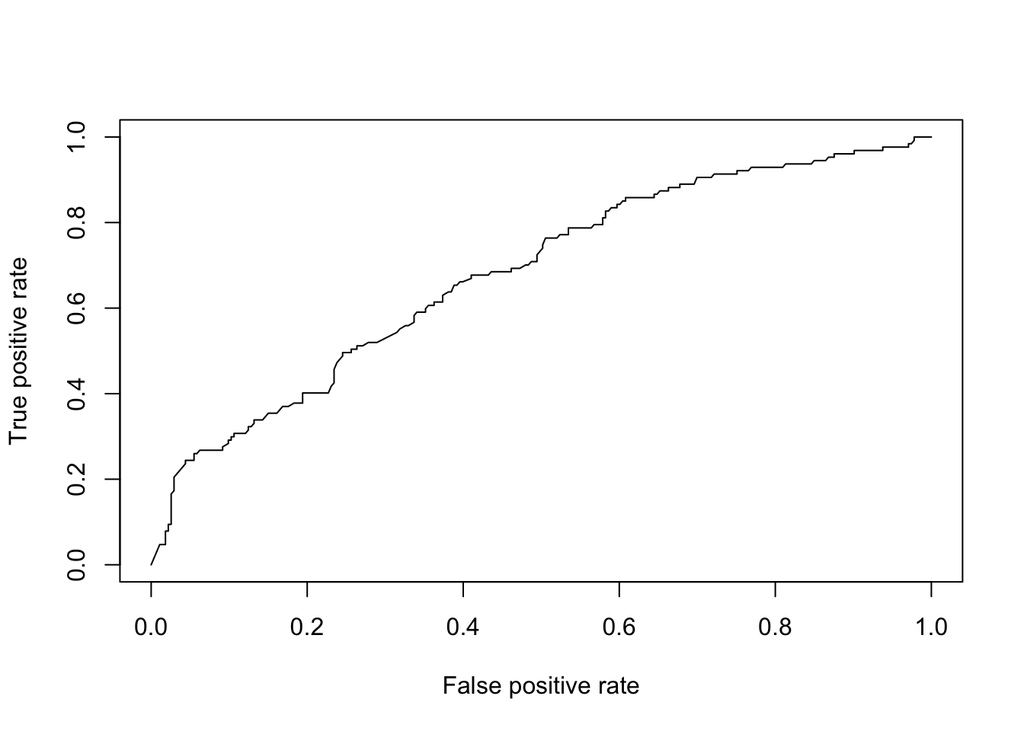

```r
pred.prob22<-prediction(pred.prob2, mydata$admit )
pred.prob22f<-performance(pred.prob22, measure='tpr', x.measure='fpr')
plot(pred.prob22f)
```

```r
auc2<-performance(pred.prob22, measure='auc')
auc2@y.values[[1]]
```

```
## [1] 0.6801073
```